# Preventable Mortality Under 75: District-Level Variation in England

## Findings

### Deprivation is a strong predictor of preventable mortality, but not the whole story

Across English districts, IMD deprivation score is positively associated with preventable mortality under 75 for both men and women. Districts with the highest deprivation scores (Blackpool, Manchester, Liverpool, Middlesbrough) consistently show the highest mortality rates. Districts with the lowest deprivation (Hart, Wokingham, South Cambridgeshire) show the lowest.

However, deprivation alone does not fully explain the variation. A significant number of districts perform substantially better or worse than their deprivation score would predict.

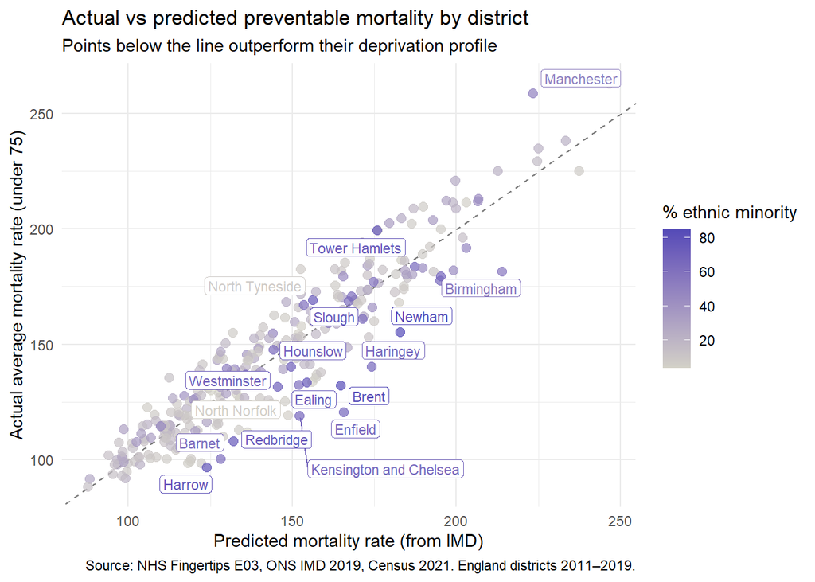

Figure 1: Actual vs predicted preventable mortality by district

```r
district_avg <- analytical_table |>
  filter(Sex == "Persons" & Value != 0) |>
  group_by(AreaCode, AreaName) |>
  summarise(
    avg_mortality = mean(Value, na.rm = TRUE),
    avg_imd = mean(imd_score, na.rm = TRUE),
    avg_ethnicity = mean(pct_ethnic_minority, na.rm = TRUE),
    .groups = "drop"
  )

model <- lm(avg_mortality ~ avg_imd, data = district_avg)
district_avg$predicted <- predict(model, district_avg)
district_avg$residual <- district_avg$avg_mortality - district_avg$predicted

district_avg$label <- ifelse(
  abs(district_avg$residual) > 25 | district_avg$avg_ethnicity > 70,
  district_avg$AreaName, NA
)

ggplot(district_avg, aes(x = predicted, y = avg_mortality, colour = avg_ethnicity)) +
  geom_abline(slope = 1, intercept = 0, linetype = "dashed", colour = "grey50") +
  geom_point(alpha = 0.7, size = 2.5) +
  geom_label_repel(aes(label = label), size = 3, max.overlaps = 15,
                   fill = "white", label.padding = 0.15) +
  scale_colour_gradient(low = "#D3D1C7", high = "#534AB7",
                        name = "% ethnic minority") +
  labs(
    title = "Actual vs predicted preventable mortality by district",
    subtitle = "Points below the line outperform their deprivation profile",
    x = "Predicted mortality rate (from IMD)",
    y = "Actual average mortality rate (under 75)",
    caption = "Source: NHS Fingertips E03, ONS IMD 2019, Census 2021. England districts 2011–2019."
  ) +
  theme_minimal()
```

### High ethnic minority districts systematically outperform their deprivation profile, but the mechanism is contested

Districts with high ethnic minority populations (particularly London boroughs) consistently sit below the deprivation-predicted mortality line. Harrow, Enfield, Barnet, Newham, and Brent all show substantially lower mortality than their IMD scores would predict.

This pattern is concentrated in London but not exclusive to it. The consistency across multiple London boroughs suggests a structural rather than coincidental explanation. However the outlier analysis identifies an important asymmetry: formally identified outlier districts split into two distinct groups with different characteristics.

**Negative residual districts** (lower mortality than predicted) are predominantly high ethnic minority London boroughs: Enfield, Haringey, Brent, Barnet, Harrow, Newham, Redbridge, Ealing, Kensington and Chelsea. These fall within North Central, North West, and North East London ICBs, which collectively represent the highest NHS service density in England. Active health inequalities monitoring programmes are documented for multiple of these CCGs during the study period.

Tower Hamlets is a different case: it was the top-ranked CCG in England for diabetes, COPD, and CVD management in 2012/13, yet still shows higher-than-predicted mortality. This suggests either that IMD understates the depth of structural deprivation in Tower Hamlets, or that process-level clinical quality metrics do not translate directly into reductions in the specific causes classified as preventable under the ONS definition.

**The causal identification problem.** NHS resource allocation under Core20PLUS5 and its predecessor frameworks directs funding to areas with high IMD scores. If funding allocation follows deprivation, and service access and quality are what actually reduce mortality, the observed correlation between IMD and mortality is partially a policy artefact: it reflects the NHS allocation formula operating, not an independent relationship between poverty and preventable death. Separating the effect of deprivation per se from the effect of NHS investment it generates requires ICB-level budget data and programme mapping that is not included in this pipeline.

Three explanations are consistent with the observed pattern and cannot be distinguished at area level: health selection among economic migrants (structural selection through visa income thresholds), urban NHS service concentration (higher infrastructure density in London ICBs), and NHS investment effects (Core20PLUS5 and predecessor frameworks targeting deprived areas). All three predict lower mortality in deprived urban areas with high ethnic minority populations. All three carry different implications for policy.

### The gender gap widens with deprivation

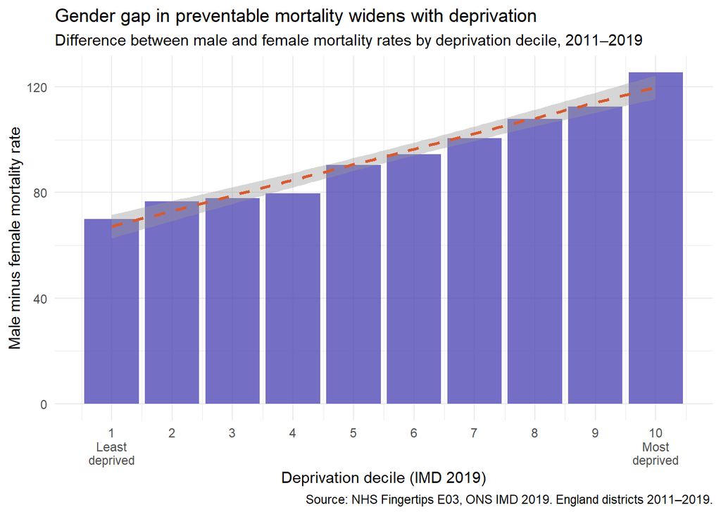

Figure 2: Gender gap in preventable mortality by deprivation decile

```r
district_gender <- analytical_table |>
  filter(Sex %in% c("Male", "Female") & Value != 0) |>
  mutate(imd_decile = ntile(imd_score, 10)) |>
  group_by(imd_decile, Sex) |>
  summarise(
    avg_mortality = mean(Value, na.rm = TRUE),
    .groups = "drop"
  )

gender_gap <- district_gender |>
  tidyr::pivot_wider(names_from = Sex, values_from = avg_mortality) |>
  mutate(gap = Male - Female)

ggplot(gender_gap, aes(x = imd_decile, y = gap)) +
  geom_col(fill = "#534AB7", alpha = 0.8) +
  geom_smooth(method = "lm", se = TRUE, colour = "#D85A30", linetype = "dashed") +
  scale_x_continuous(breaks = 1:10,
                     labels = c("1\nLeast\ndeprived", 2:9, "10\nMost\ndeprived")) +
  labs(
    title = "Gender gap in preventable mortality widens with deprivation",
    subtitle = "Difference between male and female mortality rates by deprivation decile, 2011–2019",
    x = "Deprivation decile (IMD 2019)",
    y = "Male minus female mortality rate",
    caption = "Source: NHS Fingertips E03, ONS IMD 2019. England districts 2011–2019."
  ) +
  theme_minimal()
```

Women have lower preventable mortality than men across all deprivation levels. However the gap is not constant; it widens substantially as deprivation increases, meaning men bear a disproportionately greater mortality burden in the most deprived areas.

### Ethnic minority composition predicts male outcomes more consistently than female

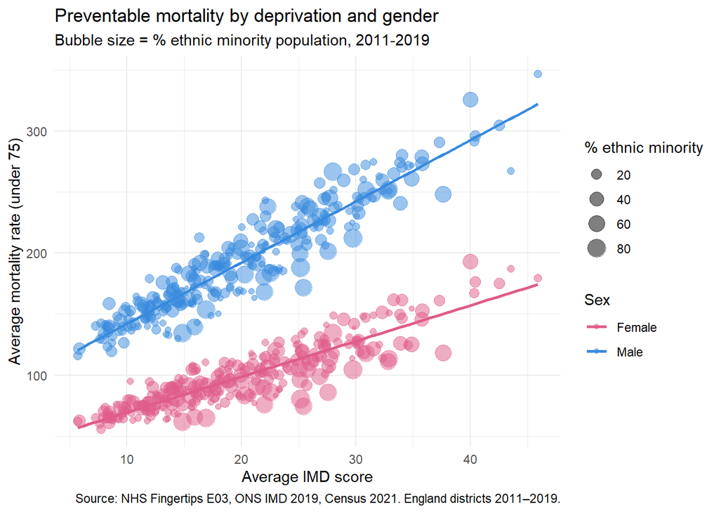

Figure 3: Preventable mortality by deprivation and gender

```r
ggplot(gender_split, aes(x = avg_imd, y = avg_mortality, color = sex)) +
  geom_point(aes(size = avg_ethnicity), alpha = 0.5) +
  geom_smooth(method = "lm", se = FALSE) +
  scale_color_manual(values = c("Female" = "#E05C8A", "Male" = "#378ADD")) +
  labs(
    title = "Preventable mortality by deprivation and gender",
    subtitle = "Bubble size = % ethnic minority population, 2011-2019",
    x = "Average IMD score",
    y = "Average mortality rate (under 75)",
    color = "Sex",
    size = "% ethnic minority",
    caption = "Source: NHS Fingertips E03, ONS IMD 2019, Census 2021. England districts 2011–2019."
  ) +
  theme_minimal()
```

This is consistent with gendered migration pathways. Male economic migrants, who disproportionately enter on skilled work visas with income thresholds, are more strongly health-selected than women who more commonly migrate through family reunion routes. The healthy migrant effect, to the extent it operates, is therefore likely a gendered phenomenon that applies more consistently to men than to women.

**The ONS preventable mortality cause list is not gender-biased.** Maternal and obstetric conditions are included and women are not systematically underrepresented in the definition. The observed gender gap is real. The evidence suggests women show greater general resilience to the mortality effects of socioeconomic determinants of health, a pattern that holds across multiple international datasets and is not explained by measurement differences. The mechanism behind this resilience, and why it appears to attenuate the deprivation-mortality relationship more strongly for women than men, is an open research question. This analysis identifies the pattern but cannot explain it; further research disaggregating cause-specific mortality by sex and deprivation level is needed to understand which specific health pathways account for the difference.

If NHS targeted investment is suppressing mortality in the most deprived areas, a narrowing gap between high and low deprivation groups would be consistent with that effect, even if the absolute levels remain higher in deprived districts.

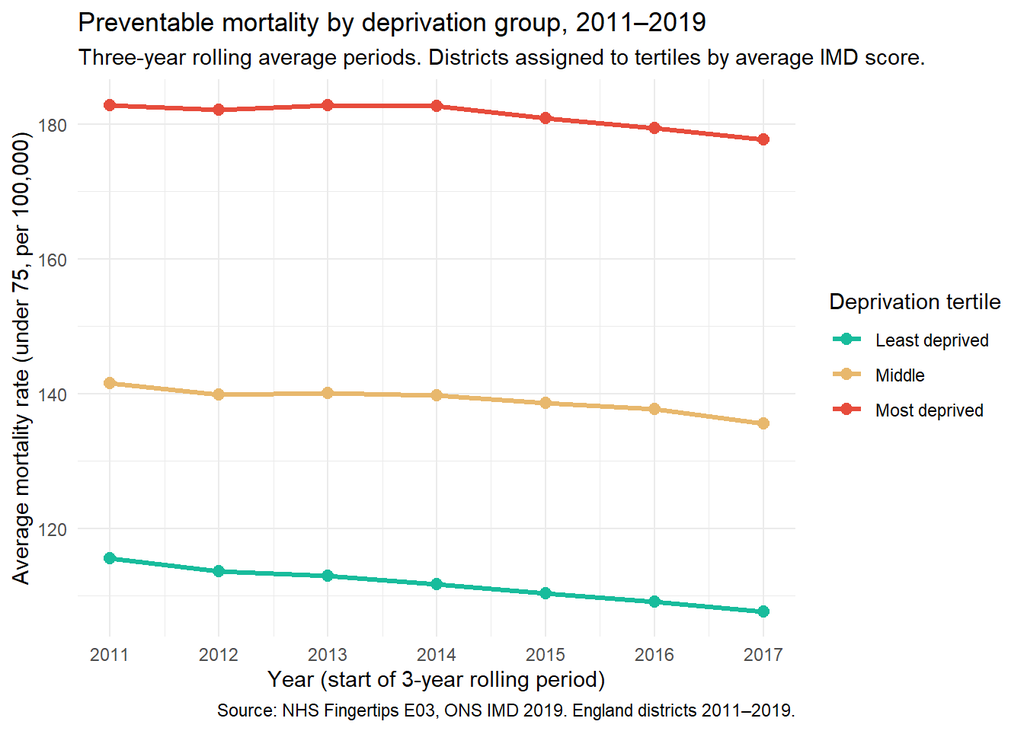

Figure 10: Preventable mortality by deprivation tertile, 2011–2019

```r
dep_trend <- panel |>
  filter(Sex == "Persons" & Value != 0) |>
  inner_join(persons_avg |> select(AreaCode, avg_imd), by = "AreaCode") |>
  mutate(
    dep_tertile = ntile(avg_imd, 3),
    dep_group = factor(dep_tertile, levels = 1:3,
                       labels = c("Least deprived", "Middle", "Most deprived"))
  ) |>
  group_by(dep_group, year) |>
  summarise(avg_mortality = mean(Value, na.rm = TRUE), .groups = "drop")

ggplot(dep_trend, aes(x = year, y = avg_mortality, colour = dep_group)) +
  geom_line(linewidth = 1.2) +
  geom_point(size = 2.5) +
  scale_colour_manual(
    values = c("Least deprived" = "#18BC9C", "Middle" = "#E8B86D", "Most deprived" = "#E74C3C"),
    name = "Deprivation tertile"
  ) +
  scale_x_continuous(breaks = 2011:2017) +
  labs(
    title = "Preventable mortality by deprivation group, 2011–2019",
    subtitle = "Three-year rolling average periods. Districts assigned to tertiles by average IMD score.",
    x = "Year (start of 3-year rolling period)",
    y = "Average mortality rate (under 75, per 100,000)",
    caption = "Source: NHS Fingertips E03, ONS IMD 2019. England districts 2011–2019."
  ) +
  theme_minimal()
```

### Greater Manchester shows persistently higher residuals outside the NHS allocation framework

Greater Manchester Health and Social Care was devolved to the Combined Authority in April 2016. Under this arrangement the GM footprint manages a pooled health and social care budget outside the standard NHS England resource allocation formula. It does not receive NHS Core20PLUS5-targeted funding through the same channel as other ICBs.

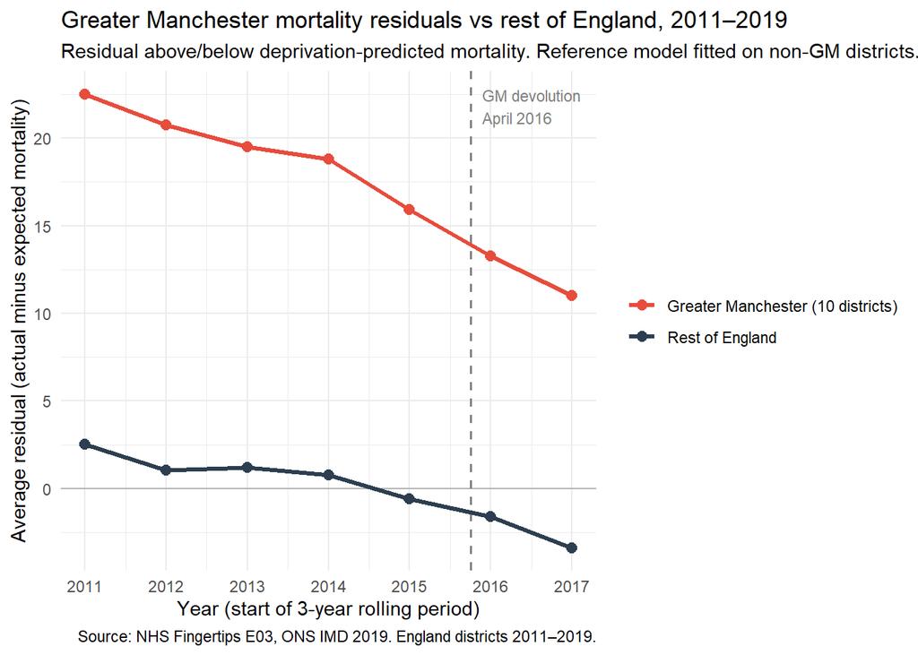

Figure 11: Greater Manchester residuals vs rest of England, 2011–2019

```r
gm_codes <- c("E08000001", "E08000002", "E08000003", "E08000004",
               "E08000005", "E08000006", "E08000007", "E08000008",
               "E08000009", "E08000010")

persons_panel <- panel |>
  filter(Sex == "Persons" & Value != 0) |>
  mutate(gm = AreaCode %in% gm_codes)

model_ref <- lm(Value ~ imd_score, data = persons_panel |> filter(!gm))
persons_panel <- persons_panel |>
  mutate(
    expected     = predict(model_ref, newdata = persons_panel),
    resid_deprev = Value - expected
  )

gm_resid <- persons_panel |>
  group_by(year, gm) |>
  summarise(avg_resid = mean(resid_deprev, na.rm = TRUE), .groups = "drop") |>
  mutate(group = ifelse(gm, "Greater Manchester (10 districts)", "Rest of England"))

ggplot(gm_resid, aes(x = year, y = avg_resid, colour = group)) +
  geom_hline(yintercept = 0, colour = "grey70") +
  geom_vline(xintercept = 2015.75, linetype = "dashed", colour = "grey50", linewidth = 0.7) +
  geom_line(linewidth = 1.2) +
  geom_point(size = 2.5) +
  annotate("text", x = 2015.9, y = Inf, vjust = 1.5,
           label = "GM devolution\nApril 2016", hjust = 0, size = 3, colour = "grey50") +
  scale_colour_manual(
    values = c("Greater Manchester (10 districts)" = "#E74C3C", "Rest of England" = "#2C3E50"),
    name = NULL
  ) +
  scale_x_continuous(breaks = 2011:2017) +
  labs(
    title = "Greater Manchester mortality residuals vs rest of England, 2011–2019",
    subtitle = "Residual above/below deprivation-predicted mortality. Reference model fitted on non-GM districts.",
    x = "Year (start of 3-year rolling period)",
    y = "Average residual (actual minus expected mortality)",
    caption = "Source: NHS Fingertips E03, ONS IMD 2019. England districts 2011–2019."
  ) +
  theme_minimal()
```

The ten Greater Manchester districts show persistently positive residuals across the full study period; they have higher mortality than their deprivation profile predicts, relative to the rest of England. This pattern pre-dates the April 2016 devolution and continues through it; the devolution line is marked not because it produces a visible break in trend but because it provides the structural explanation for why the gap exists at all.

The argument is not that devolution caused the gap. It is that Greater Manchester’s long-standing position outside the mainstream NHS targeted allocation framework, which predates 2016, means that the mechanisms linking deprivation to NHS investment to mortality outcomes operate differently there. Where the rest of England’s deprived districts have received sustained, formula-driven NHS resource allocation since 2001, Greater Manchester has always had a different funding relationship with NHS England. The natural experiment that devolution formalises was already running.

This is the dataset’s most direct test of the service access hypothesis. Two regions of similar deprivation, one within the NHS targeted allocation framework and one outside it, produce systematically different mortality outcomes relative to prediction. The direction of the difference is consistent with NHS targeted funding reducing mortality below the level that deprivation alone would predict.

## Root cause analysis

The statistical findings point to a pattern but do not establish a causal mechanism. Before drawing policy conclusions, it is necessary to set out the competing causal chains and what each implies.

**The standard deprivation narrative** runs: poverty → poor health behaviours and living conditions → higher mortality. IMD predicts mortality because it captures material conditions that cause ill health. Under this account, reducing deprivation reduces mortality, and targeting the most deprived areas is the correct allocation strategy.

**The service access narrative** runs: deprivation → NHS targeting → funding allocation → service access and quality → mortality outcomes. IMD predicts mortality not because deprivation causes death directly, but because IMD is the input variable for the allocation formula that determines how much NHS resource an area receives. Under this account, IMD and mortality are correlated because they are both downstream of the same targeting mechanism. The observed association is partially a policy artefact. This is not a theoretical claim. NHS resource allocation policy between 2001 and 2011 was directly associated with a reduction in absolute health inequalities in England (Barr et al., BMC Medicine 2014). Manchester, operating outside that formula, provides a natural experiment: its positive residual across the study period is consistent with the removal of targeted funding producing worse outcomes relative to deprivation than areas that remain in the scheme.

**The migration selection narrative** runs: visa rules → health-selected migrants → urban concentration → suppressed area-level mortality. Economic migrants are selected for health through income thresholds, fitness requirements, and the precarity of immigration status. They concentrate in urban areas with work, which happen to be areas with high NHS infrastructure density. Under this account, ethnicity composition predicts mortality because it proxies for both selection effects and service access simultaneously.

These three narratives are not mutually exclusive. They predict the same observable pattern (deprived urban high-ethnicity areas with lower-than-expected mortality) for different reasons. The critical implication of the service access narrative is that it strengthens the case for the current Core20PLUS5 framework rather than challenging it: if NHS investment in deprived areas is part of what suppresses mortality there, then the correlation between deprivation and mortality observed in this and other studies is partly evidence that targeted funding works. Removing or redirecting that funding on the basis that some deprived areas have lower-than-expected mortality would risk dismantling the mechanism that produces the lower mortality.

The gender findings add a further dimension. If IMD underweights female-specific dimensions of economic vulnerability, because it measures household and area aggregates rather than individual exposure, then women in deprived areas are systematically underserved by allocation models that use composite IMD scores without sex-stratification.

## Conclusions

Deprivation is the strongest single predictor of preventable mortality under 75 across English districts. The analysis confirms this relationship is real, persistent across nine years, and operates differently across population types. Three substantive findings emerge.

First, formally identified outlier districts split into two patterns: a cluster of high ethnic minority London boroughs with lower-than-expected mortality, concentrated in ICBs with high service density and documented health inequalities programmes; and a set of positive outliers (including Manchester and Tower Hamlets) where mortality exceeds prediction despite above-average NHS investment or quality. The former pattern is consistent with service access and migration selection effects. The latter suggests that IMD may understate structural deprivation in some urban areas, or that process-level clinical quality measures do not translate directly to mortality reductions.

Second, the mortality burden of deprivation falls disproportionately on men. The gender gap widens as deprivation increases. The ONS preventable mortality cause list is not gender-biased; women are not underrepresented, and the gap is real. Women show greater general resilience to the mortality effects of socioeconomic determinants of health, a pattern consistent with international evidence. The mechanism is not explained by this analysis and represents a priority for further research: understanding which specific health pathways produce the differential, and whether they are amenable to targeted intervention, is directly relevant to how ICBs design sex-stratified preventable mortality programmes.

Third, the analysis identifies a causal identification problem in the use of IMD as a mortality predictor. Because NHS resource allocation follows IMD (directing funding to the most deprived areas), the observed correlation between IMD and mortality is partially endogenous. Distinguishing the direct effect of deprivation from the effect of NHS investment it generates is not possible with this dataset and requires ICB-level budget data joined to mortality outcomes.

Area-level deprivation measures like IMD remain the most practical available signal for NHS targeting. The findings here do not undermine Core20PLUS5; they suggest the framework may be working in London ICBs in ways that suppress the very mortality signal used to justify it. The implication is not to abandon deprivation-based targeting but to supplement it: with sex-stratified need assessments, with individual-level data where available, and with explicit accounting for the NHS investment effects that make deprived area mortality appear lower than raw deprivation would predict.

## Future directions

Several avenues would strengthen or refute the arguments raised here. Joining ICB-level per-capita NHS spend to district mortality outcomes would directly test the service investment hypothesis. Replacing the static 2021 Census ethnic composition variable with time-varying estimates (using ONS mid-year population estimates at district level for 2011, 2015, and 2021) would address the temporal mismatch and allow testing of whether the protective effect weakens as migrant communities become more settled across generations. Adding a 2011 Census comparison would reveal whether the ethnic minority outlier pattern was already present at the start of the study or emerged over the period.

A cause-specific breakdown of the preventable mortality indicator (separating male-prevalent from female-prevalent causes) would test whether the observed gender gap reflects true health differences or a definitional bias in the pre-2019 ONS cause list. Grouping districts by their parent ICB and modelling at ICB level rather than district level would align the unit of analysis with actual NHS decision-making.

Secondary research mapping documented NHS intervention programmes to each formally identified outlier district, as begun in Table 9, should be extended and formalised before the outlier analysis is used to support any policy argument.